# R Bootcamp

## Outline

- Installing R
- Installing Rstudio
  - Getting to know the power of Rstudio
- Installing additional functionality

## What is R?

R is a programming language (Gnu-S)

R is an environment for statistical computing and graphics

R is not a "stats package"

It is never useful to ask if you can do something in R.

- R's only limitation is your programming ability and creativity.

## Installing R

Installing R

- Pick a mirror (closer better but doesn't really matter. 0-Cloud is fine.)
- Pick an OS
- Windows: Download base
- MAC: first .pkg file
- Linux: follow instructions according to your flavor

You now have a fully functioning statistical programming environment.

However… you will likely never need to use base R directly

## Installing Rstudio

Installing Rstudio

Cross-platform

- Go to website
- Download
- Install

## Using Rstudio

## What is Rstudio?

Integrated Development Environment

## Using Rstudio

Making programming easier

- Code completion
- Keyboard shortcuts
- Debugging

But lots more…

## Using Rstudio

- **Web-enabled**
  - Interactive graphics
  - Create webpages, presentations (like this one) and more
- **Projects**
- **Built in version-control**
- Package development

## Multiple File Types

- R scripts
- R markdown
- Latex
- Presentation
- General text/code editor that recognizes several other languages

## Web-enabled

Not only can you easily publish your efforts to html, you can even code directly in html, css, javascript etc.

The Rstudio group and others have a suite of packages devoted to interactive visualizations that often will require no more effort than standard plots

## Projects

Projects are a way to keep you research focused

Easily pick up where you left off

Easily switch from one project to another

Version control

## Version Control

Any project is able to take advantage of version control

- Git
- SVN

Among the many benefits, version-control provides peace of mind for research reproducibility, enhances collaboration, and allows one to keep on top of all the changes a typical research endeavor undergoes.

## Adding Functionality

## Adding Functionality

R's true power comes from the thousands of packages produced by the statistical and greater research communities

At this point there is a package for practically everything you'd want to do, especially when it comes to modeling

The best part is that adding this functionality is very easy

## Installing Packages

CRAN

- Comprehensive R Archive Network
- Main place for R packages

Other

- Github (also Rforge R-forge)
- Bioconductor

To install packages there are two primary approaches with Rstudio

- install.packages function
- Using the packages tab

## Using Packages

R does not load packages in your library automatically. To do so, use the library function to select the package.

- library('packagename')

Common coding practice loads a package only at the point it's needed (rather than loading all at the beginning)

## Outline

- Creating and manipulating objects
  - Classes of objects
- Data Structures
- Using functions

## Creating and manipulating objects

In R, you will constantly create *objects* and manipulate objects with *functions*.

Objects can be anything, and this will become clear as we continue through the course.

We will use many functions over the course of the day, including building our own.

## Data Structures

The most common data structures used can be seen to posses

One type only

- Vector (may be of length 1)
  - numeric, integer, character and logical are the most commonly used
  - In addition, a special class of the integer type are factors
- Matrix
  - collection of vectors
- Array
  - beyond 2 dimensions

## Data Structures

Multiple types

- Lists
  - Dataframes
  - Perhaps most commonly used class of lists

Dataframes are what you've been using if you have experience with other statistical packages or programming languages.

Typical use is that each column represents attributes, targets etc., while rows represent observations (e.g. people, time points)

## Using functions

R is a functional language.

Functions are objects that take some input and return a **value**

They are highly flexible, in that the nature of the input can range from nothing to a couple dozen *arguments*, values can be lists of modeling output, a plot, or even another function.

## Using functions

```r
myfunction(x=someX, y=someY)
```

## Using functions

Use the matrix function to create a matrix, use c to concatentate values, use : to create sequences, and finally provide arguments pertaining to the number of rows and columns.

```r
myMatrix = matrix(c(1:3, 4:6, 7:9), nrow=3, ncol=3, byrow=T)
```

Try creating a dataframe version of the myMatrix object, called myDF. To convert a matrix object to a dataframe, use the **as.data.frame** function on it.

## Using functions

While most functions are unique, many are generic and have *methods* that will allow the function to operate differently for different classes of objects. The following demonstrates this with the commonly used **summary** function.

```r
methods(summary)
```

```
##  [1] summary.aov                    summary.aovlist*
##  [3] summary.aspell*                summary.check_packages_in_dir*
##  [5] summary.connection             summary.data.frame
##  [7] summary.Date                   summary.default
##  [9] summary.ecdf*                  summary.factor
## [11] summary.glm                    summary.infl*
## [13] summary.lm                     summary.loess*
## [15] summary.manova                 summary.matrix
## [17] summary.mlm*                   summary.nls*
## [19] summary.packageStatus*         summary.PDF_Dictionary*
## [21] summary.PDF_Stream*            summary.POSIXct
## [23] summary.POSIXlt                summary.ppr*
## [25] summary.prcomp*                summary.princomp*
## [27] summary.proc_time              summary.srcfile
## [29] summary.srcref                 summary.stepfun
## [31] summary.stl*                   summary.table
## [33] summary.tukeysmooth*
## see '?methods' for accessing help and source code
```

## Getting Started with Statistical Functions

Write and run the following lines, then use some of the following functions on those objects:

- summary
- mean
- sd
- table
- plot
- cbind

```r
x = rnorm(100)
y = 2*x + rnorm(100)
z = sample(letters[1:5], 100, replace=T)
```

## Playtime

## Outline:

- Geting data in from outside sources
- text
- statistical packages
- web
- unstructured
- Saving R objects
- Writing to common data formats
- Saving and using RData files.

## Text/flat files

read.* family of functions

- read.table (most general), read.csv, others

```r
myData = read.csv('my/file/location/myFile.csv')
```

## readr as an alternative

The readr package has similar functionality and same naming convention using underscore instead of dot.

- read_csv

Some efficiencies are built in, as well as making it easier to see if there are any issues, even if minor

In addition, the readxl package also provides the ability to read in MS Excel files (or particular sheets), without any thing additional needed.

- Doesn't fix the fact that Excel is a terrible format to keep your data in.
- You'd often still be better off writing to csv from Excel first

## Statistical Packages

In general, there appears to still be some misconception that entirely separate programs are needed to transfer data from one statistical enviornment to another.

However, this hasn't been the case for a very long time.

- Different packages have long been able to read each others' files directly
- One can *always* write to a text file (e.g. csv)

Base R comes with a package called foreign for reading in data files from various packages such as SPSS, Stata etc.

However, the haven package will read current Stata files and offers some capacity to write to spss or stata files.

## Web

A variety of data formats are web-oriented, such as json, xml, html tables and the like.

In addition, one can pull a lot of data directly via APIs (e.g. use google maps or similar to geocode your datas).

There are a variety of packages to help with this. A starting point would be the [Web Technologies Task View](https://cran.r-project.org/web/views/WebTechnologies.html).

Furthermore, a variety of packages are available to analyze or otherwise deal with the data in a streaming fashion.

## Web

Install the dplyr (for many things as we'll see), leaflet (for vis), and ggmap (for a simple geocode function that uses Google API) packages

Create an R object that is a character string of your address (or use the following for ND: 'Notre Dame, Indiana')

```r
place = ggmap::geocode('Notre Dame, Indiana')
library(dplyr); library(leaflet)
leaflet() %>%
  addTiles() %>%
  addCircles(lng=place$lon, lat=place$lat, radius=50, opacity=1, color='firebrick', fillColor = 'darkred', fillOpacity = 1)
```

[interactive chart not shown]

## Unstructured Data

*Unstructured* data doesn't really have a precise definition, and usually means anything that isn't in tabular format, with the most common example being text.

- Perhaps better would be to say it's uncommonly structured (relative to tabular data)

While there is a vast amount of ways to attack text specifically, other data might require alternative solutions.

The goal is almost always to impose a common structure in order for the data to be analyzed.

Again, R has many packages that might be of use, but it will depend on your situation

## Big Data

Big data is that which can't be housed or analyzed in a normal computing environment (e.g. even desktop with lots of horsepower could not crunch it).

R is memory intensive, and even data that can be imported might not be feasible with some types of analysis.

- Largish data that turns into four chains of thousands of simulated values for hundreds of parameters

However there are cluster computing (e.g. CRC) and distributed data solutions that make R viable in these situations as well.

AWS, Spark and other means to deal with large data sets will eventually be easy enough for average folk to enage such data through the web.

## Output: writing to common formats

Writing to some data format is typically as easy as reading it in.

- e.g. write.csv(rObject, 'fileLocation/fileName.csv')

Just as with reading the data, what package you might use for the format in question will vary, but one or two packages will cover the majority of common data scenarios.

Writing to text files pretty much ensures all other analytical programs will be able to read it.

## Saving and Using .RData files

One unique data format to get used to working with is the RData file.

When you use the functions **save** (for specific objects) or **save.image** (for all objects, i.e. your *workspace*), you have the capacity to save everything you've created to a file

When you return to using R, the **load** function on the file will restore all the objects you've created.

## Playtime

Install the readr package

Use the read_tsv (tab separated) file to read in the following data:

http://csr.nd.edu/assets/22641/testwebdata.txt

Save your workspace

- Use save.image('fileLocation/fileName.RData')
- Close out Rstudio
- Open it back up
- Use load('fileLocation/fileName.RData'), and print one of your objects to the console

## Outline

- Two approaches
  - Base R
  - Piping
- Filtering
- Selecting
- Slicing
- Using non-standard data objects

## Indexing

## Base R Indexing

Base R has a very flexible/powerful indexing system with which to get at your data.

```r
x = rnorm(10)
x[x>0 & x<1]
```

```
## [1] 0.2774292 0.4291247 0.5060559
```

A more complicated approach. Values of y in which the absolute residuals of a regression on x are greater than 1.

```r
y[abs(resid(lm(y~x))) > 1]
```

This is not the way you should be doing things, but serves as an example of the possibilities

## Base R Indexing

Indexing

Lists (or dataframes)

- ['name'] [number] to extract list elements (including data.frames)
  - myList['myelement']
  - [[ can select a single element, where [] can return multiple
- $name also
  - myData$myvariable

Matrices (or dataframes)

- [rows, columns] or ['rownames', 'columnnames']
  - myData[1:3, 6:10]
  - myData[,'var1']

see ?Extract

## Base R Indexing

For this exercise, you will work with one of the many datasets that come with a basic R installation (?datasets), but note that packages typically come with their own as well.

For the following: Examine the **iris** dataset using the str (structure) function. You do not have to do anything to get the iris data, it's an object in the base R environment.

Create a separate object that just contains the the Species column of data

Create an object containing the 10-15th rows

Note the Petal Width of the 100th observation via indexing

Bonus: subset the data to only the virginica species. Hint- use ==

## Piping

## Piping

Piping is an alternative way to successively perform data manipulation and indexing (mainly through magrittr package).

- The most common way to do so is with this symbol %>%
- However, there are other ways to do so, and some with other packages

In conjunction with dplyr, it can make data manipulation and wrangling straightforward and with very clear code.

## Piping

Install the rvest package (read html functionality).

```r
# ☻ ☻ ☻
library(dplyr); library(rvest); library(stringr)
link ="http://www.inflationdata.com/inflation/Inflation_Rate/HistoricalInflation.aspx"
html(link) %>%                                        # read a webpage
  html_table(header = TRUE) %>%                       # grab all the tables
  `[[`(1) %>%                                         # grab the first table
  select(Year, Ave.) %>%                              # select specific columns
  rename(Ave = Ave.) %>%                              # rename
  filter(Year >= 2010) %>%                            # select certain rows
  mutate(AveNum = str_extract(Ave, '[0-9].[0-9]+'),
         AveNum2 = as.numeric(str_replace(Ave, ' %', '')))  # create new variables
```

```
##   Year    Ave AveNum AveNum2
## 1 2015          <NA>      NA
## 2 2014 1.62 %   1.62    1.62
## 3 2013 1.47 %   1.47    1.47
## 4 2012 2.07 %   2.07    2.07
## 5 2011 3.16 %   3.16    3.16
## 6 2010 1.64 %   1.64    1.64
```

## Piping

Note that you can assign the results of the piped operations to create an object

```r
myObjectSubset = mydata %>%
  filter(Year > 2000)
```

Piping is especially useful for visualization, and ggvis and newer more web-directed visualization packages will typically work with standard pipe operators.

```r
library(ggvis)
iris %>%
  ggvis(x=~Petal.Length, y=~Petal.Width) %>%
  layer_points(fill:='#ff5500', fillOpacity:=.35, size:=25) %>%
  layer_smooths(stroke:='darkred')
```

## Filtering

## Filtering

Filtering (or Slicing) refers to subsetting by rows.

You have already seen how to do this with base R functionality with numbered indexing

the dplyr package has two primary functions for this

- filter
- slice

It also has other functions that can make the code clearer and easier to work wtih

```r
state.x77 %>%
  as.data.frame %>%
  filter(Frost >150) %>%
  slice(1:3)
```

```
##   Population Income Illiteracy Life Exp Murder HS Grad Frost   Area
## 1        365   6315        1.5    69.31   11.3    66.7   152 566432
## 2       2541   4884        0.7    72.06    6.8    63.9   166 103766
## 3       1058   3694        0.7    70.39    2.7    54.7   161  30920
```

## Selecting

## Selecting

Selecting refers to the selection of columns and with dplyr again you get enhanced functionality and clarity

```r
iris %>%
  select(starts_with('Petal')) %>%
  slice(1:2)
```

```
##   Petal.Length Petal.Width
## 1          1.4         0.2
## 2          1.4         0.2
```

## Aggregation

Oftentimes we engage in such operations in order to obtain summary information about groups.

```r
iris %>%
  group_by(Species) %>%
  summarise_each('mean')
```

```
## Source: local data frame [3 x 5]
##
##      Species Sepal.Length Sepal.Width Petal.Length Petal.Width
## 1     setosa        5.006       3.428        1.462       0.246
## 2 versicolor        5.936       2.770        4.260       1.326
## 3  virginica        6.588       2.974        5.552       2.026
```

```r
state.x77 %>%
  data.frame %>%
  mutate(region = state.region) %>%
  group_by(region) %>%
  tally
```

```
## Source: local data frame [4 x 2]
##
##          region  n
## 1     Northeast  9
## 2         South 16
## 3 North Central 12
## 4          West 13
```

## Using non-standard data

Examples of non-standard data:

- text
- images
- spatial data (e.g. maps)
- web-oriented (json, xml)

Most of the data manipulation of such objects will be to put into a more analyzable format.

You will likely have to use package specific functions (e.g. jsonlite)

## Outline

Functions

- Review of using
- Writing your own

## Using functions

## Using functions

Functions are extremely important in the R world.

- they are themselves objects and can be used as such

The key thing to remember is that functions (almost always) take specific inputs and always return a value

Every R helpfile states explicitly the syntax required to use a function

The basic components

- argument list
- body
- environment

## Arguments

Note that not all arguments are required, and some will have default values.

It is important to know the arguments of any function you use, or you might be missing out on quite a bit, or not understand why you're getting an error.

As an example, examine the arguments for the mean function (i.e. type ?mean for the help file)

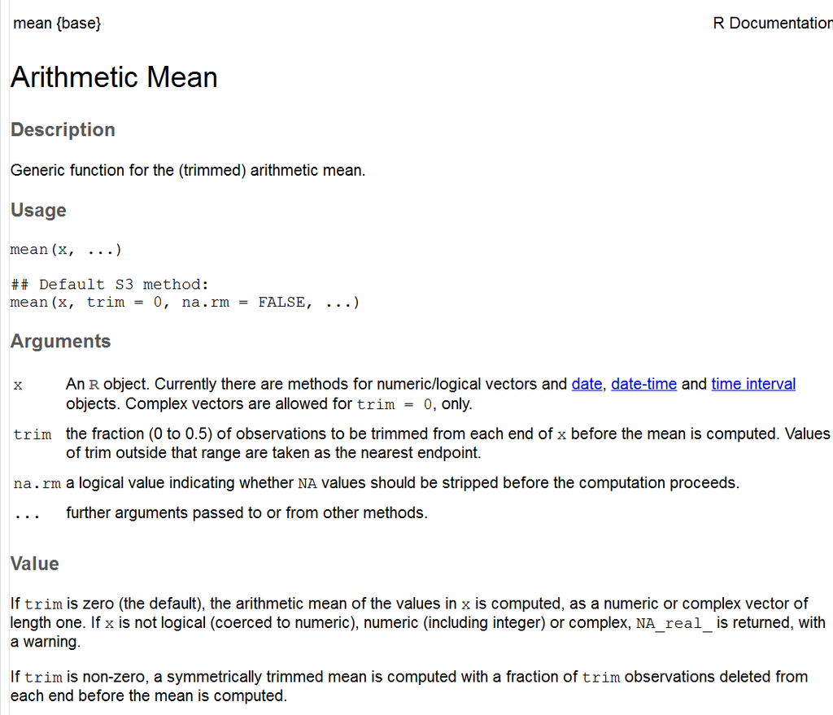

## Body

The body of a function is where all the code that works on those arguments

Type median.default at your console to see the body of median, which is fairly simple as far as functions go.

```r
median.default
```

```
## function (x, na.rm = FALSE)
## {
##     if (is.factor(x) || is.data.frame(x))
##         stop("need numeric data")
##     if (length(names(x)))
##         names(x) <- NULL
##     if (na.rm)
##         x <- x[!is.na(x)]
##     else if (any(is.na(x)))
##         return(x[FALSE][NA])
##     n <- length(x)
##     if (n == 0L)
##         return(x[FALSE][NA])
##     half <- (n + 1L)%/%2L
##     if (n%%2L == 1L)
##         sort(x, partial = half)[half]
##     else mean(sort(x, partial = half + 0L:1L)[half + 0L:1L])
## }
## <bytecode: 0x000000001510c9d8>
## <environment: namespace:stats>
```

## Body

Note that many of R's core functions actually call other functions that are written in C for faster computation.

If they are written well, you will typically see much of the first part devoted to error checking.

A good way to start learning decent coding style is by looking at code from base R functions.

## Environment

The environment is the frame or map of the location of the function's variables.

Its purpose is primarily to bind names to a set of values

What do you think the last line will produce?

```r
b = 3

f = function(b){
  return(b)
}

f(2)

f = function(){
  return(b)
}
f()
```

## Environment

In the first case, the reason 2 is returned instead of 3 is because the first environment searched to locate b is the the one created by the function. As it is passed as an argument, the value associated with the argument is returned.

In the second case, b is not found in the current (function) environment, so the global environment is searched.

```r
f = function(){
  print(environment())
  # return(b)
}
f(); environment()
```

```
## <environment: 0x000000001544d5c8>
## <environment: R_GlobalEnv>
```

This will be more important when writing your own functions, and more so if you create your own package.

However, it's important to at least be aware of environments to better understand how functions are working when you use them.

## Writing your own functions

## Writing your own functions

Once you get the hang of R, you'll want to write your own functions to further make your data wrangling and exploration efficient.

Furthermore, functions aid reproducibility.

A simple rule is, if you've written the same line of code more than twice, you should probably write a function the does the operation you're attempting.

## Writing your own functions

And it doesn't have to be complicated.

As noted, Functions take arguments and return values.

To create a function, we use the following approach:

```r
funcName = function(argsGoHere){
  Body
  .
  .
  .

  Value to be returned
}
```

## Writing your own functions

The following returns 'Positive' if the input is greater than zero, 'Negative' if not.

```r
posNeg = function(x){
  result = ifelse(sum(x) > 0, 'Positive', 'Negative')
  result
}

randomData = rnorm(10)
posNeg(x=randomData)
```

```
## [1] "Negative"
```

This does the job but could be made much better. Can you think of any ideas for improvement?

## Writing your own functions

Suggestions:

- error handling
- support for zero values
- perhaps add an argument for converting to factor or binary

## Functionals

Remember that functions are objects.

- As such, they can be passed as arguments to other functions, while still returning a vector of some kind

We will demonstrate some very important *functionals* later.

At that point we will also see some *anonymous functions*, in which we create a simple function on the fly.

There are also functions that return functions.

## Create a function

Write a function that does the following:

Take an input and return a list object containing the mean, sd, and sum.

For the purposes of this exercise, in the body of the function create separate objects for each thing to return, and combine them into a list.

Use a snippet to get started (type fun and hit tab).

## Debugging

Rstudio's debugger makes also makes testing very easy.

As an example, one can use a function like debugonce to start the debugging process.

```r
debugonce(myfunc)
myfunc(arg)
```

Try it with the function you just created.

## Outline

- Standard looping
- Using functionals
- Vectorized approaches
- Parallelizing

## Iterative Programming

## Standard looping

Data manipulation involves a lot of repeated operations, and R shines in this area in that it makes a lot of this easier.

You'll often see iterative programming within a function, though it can be and often is used in the normal course of programming.

The typical approach seen in other languages can be used, and sometimes is still the way to go.

Calculate column means:

```r
# million column matrix
d = matrix(rnorm(10000000), nrow=10)    # might take a second or two
dMeans = numeric(ncol(d))               # not necessary but does speed up explicit loops to predefine the object

# The following may take up to ~ 10 seconds
for (i in 1:ncol(d)){
  dMeans[i] = mean(d[,i])
}
```

## Standard looping

One may loop:

- directly over elements (less optimal)
- over the numeric indices (as the in that demo, possibly the most common in the R community)
- over the names

## Standard looping

A more general way to loop is with a while in place of a for.

The loop will run until some condition is met.

Any for loop can be written as a while statement.

```r
n = 1
while(n <= ncol(d)){
  dMeans[n] = mean(d[,n])
  n = n + 1
}
```

## If Else

Within functions you will often see something like the following:

```r
if(conditionMet){
  doThis
} else if(otherConditionMet) {
  doThat
} else {
  doSomethingElse
}
```

For more on for, while, and if…else constructs see ?Control.

## Looping Alternatives: Vectorized Code

While standard looping works, other approaches are available, and some *vectorized* operations can reduce code and are often faster.

Vectorizing your code means working on whole objects rather than iterating over individual elements.

## Looping Alternatives: Vectorized Code

Consider the following loop:

```r
a = rnorm(10)
b = rnorm(10)

for(i in seq(10)){
  message(a[i] + b[i])
}
```

The following is easier to write, clearer to read, and faster:

```r
a + b
```

## Looping Alternatives: Functionals

Apply the mean function to the columns. Similar time as a loop in this case but cleaner code. They also have parallelized versions meaning that their speed can be increased quite a bit.

```r
dmeans = apply(d, 2, mean) # the 2 specifies columns
```

Faster.

```r
dmeans = colMeans(d)
```

## Iterative Programming

The vectorized approach works in a lot of other places also.

```r
myvar = 1:100
myvar[sample(myvar, 50)] = NA  # insert 50 missing values
sum(is.na(myvar))
myvar[is.na(myvar)] = 0  # change missing to 0
any(is.na(myvar))

1:10 >= 5  # which of the sequence 1:10 is greater or equal to 5

rowSums(d > 0)  # count values greater than zero for each row
```

```
## [1] 50
## [1] FALSE
##  [1] FALSE FALSE FALSE FALSE  TRUE  TRUE  TRUE  TRUE  TRUE  TRUE
##  [1] 500172 500014 500230 499986 500501 500293 500732 499196 499581 500193
```

## Your turn

## Your turn

Using either matrix below (or both), perform a row or column operation with two different approaches.

Suggestions:

- Calculations like rowMeans, colSums
- Operators == != > <
- any which all

```r
nums = matrix(sample(1:3, 9, replace = T), 3, 3)
lets = matrix(letters[1:9], 3, 3)
```